# Using `imhen`

Marc Choisy

2018-08-02

[figure not shown]

## Installation and loading

You can install `imhen` from [GitHub](https://github.com/choisy/imhen)

```r
> # install.packages("devtools")
> devtools::install_github("choisy/imhen", build_vignettes = TRUE)
```

Once installed, you can load the package:

```r
> library(imhen)
```

## Usage examples

The package contains two dataframes. The first one is `meteo` which contains the climatic variables `Tx`, `Ta`, `Tm`, `aH`, `rH`, `Rf` and `Sh` plus time (`year` and `month`) and space (`station`) information:

```r
> head(meteo)
  year    month   Ta   Tx   Tm    Rf rH Sh   aH station
1 1961  January 13.9 19.1 10.5   5.3 82 NA 13.1 Bac Kan
2 1961 February 15.1 18.3 13.2  21.5 85 NA 14.7 Bac Kan
3 1961    March 19.6 23.2 17.5  85.4 87 NA 20.1 Bac Kan
4 1961    April 23.5 28.1 20.5 185.8 87 NA 24.8 Bac Kan
5 1961      May 25.8 31.2 22.1  34.9 83 NA 27.1 Bac Kan
6 1961     June 26.9 32.6 23.1 314.7 83 NA 29.3 Bac Kan
```

Note that the data frame is not “complete”, with some combinations of the `year`, `month` and `station` being missing:

```r
> table(with(meteo, table(year, month, station)))

    0     1
 7980 37848
```

The second one is `stations` which contains the coordinates (`longitude` and `latitude`) and the `elevation`:

```r
> head(stations)
           coordinates   station longitude  latitude elevation
1 (105.8167, 22.13333)   Bac Kan  105.8167 22.133333       174
2    (106.2, 21.28333) Bac Giang  106.2000 21.283333         7
3 (105.7167, 9.283333)  Bac Lieu  105.7167  9.283333         2
4       (106.05, 21.2)  Bac Ninh  106.0500 21.200000         5
5    (106.6, 10.03333)    Ba Tri  106.6000 10.033333        12
6    (106.4, 21.08333)     Ba Vi  106.4000 21.083333        20
```

### Mapping the climatic stations

We can transform the climatic stations coordinates into a spatial object:

```r
> library(gadmVN)
> library(sp)
> vietnam <- gadm(level = "country")
> #coordinates(stations) <- ~ longitude + latitude
> # to check if the projection system is the same
> proj4string(stations)
[1] "+proj=longlat +ellps=WGS84 +datum=WGS84 +no_defs +towgs84=0,0,0"
> vietnam@proj4string
CRS arguments:
 +proj=longlat +datum=WGS84 +no_defs +ellps=WGS84 +towgs84=0,0,0
```

And plot the stations on the map:

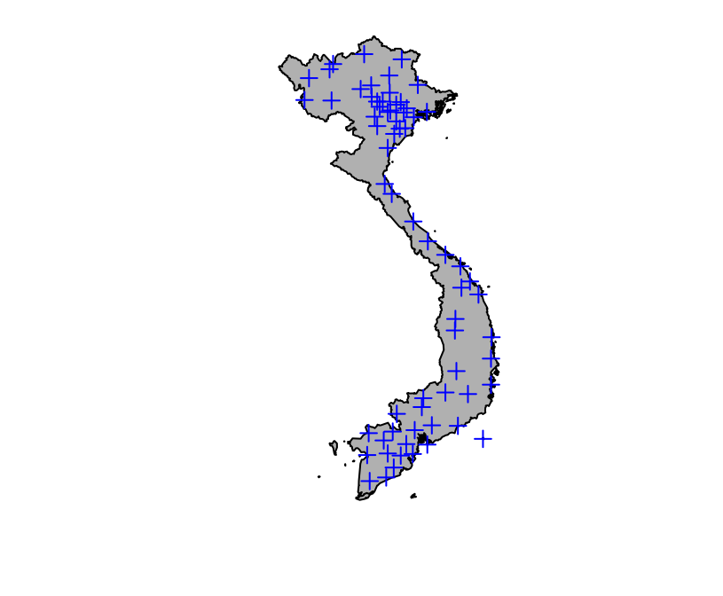

```r
> plot(vietnam, col = "grey")
> points(stations, col = "blue", pch = 3)
```

### Visualizing the climatic stations elevations

We can also look at the elevations of the climatic stations:

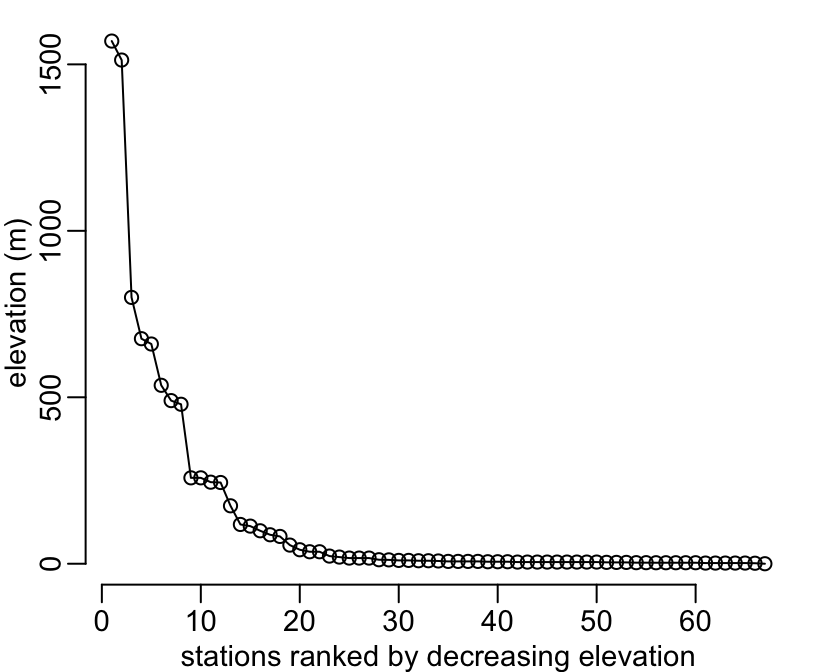

```r
> plot(sort(stations$elevation, TRUE), type = "o",
+      xlab = "stations ranked by decreasing elevation", ylab = "elevation (m)")
```

### Exploring the climatic variables

Let’s look at the temperatures:

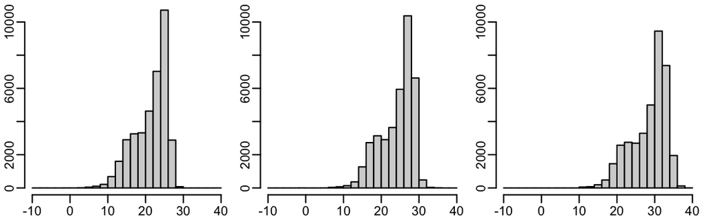

```r
> val <- c("Tm", "Ta", "Tx")
> T_range <- range(meteo[, val], na.rm = TRUE)
> breaks <- seq(floor(T_range[1]), ceiling(T_range[2]), 2)
> par(mfrow = c(1, 3))
> for(i in val)
+   hist(meteo[[i]], breaks, ann = FALSE, col = "lightgrey", ylim = c(0, 10500))
```

Looks good. Let’s check the consistency of the values:

```r
> for(i in val) print(range(meteo[[i]], na.rm = TRUE))
[1] -9.256667 29.900000
[1]  0.0 35.8
[1]  5.7 39.3
> with(meteo, any(!((Tm <= Ta) & (Ta <= Tx)), na.rm = TRUE))
[1] FALSE
```

Let’s look at the other variables:

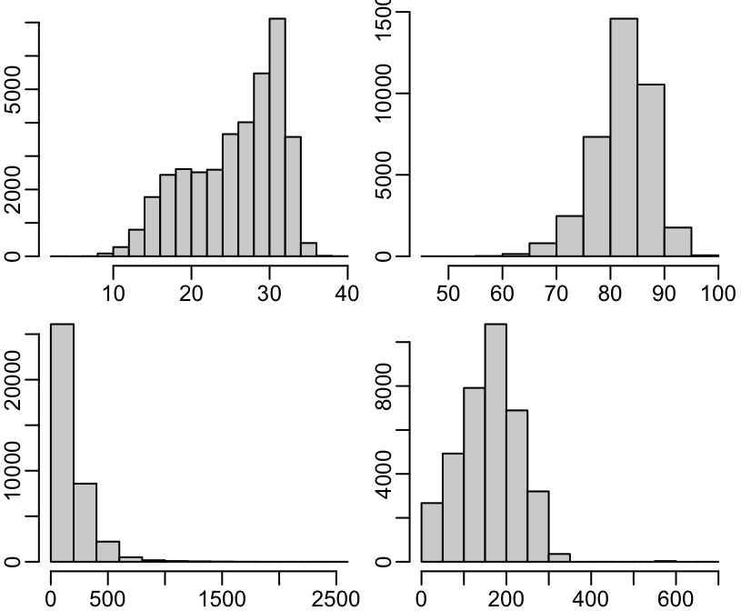

```r
> val <- c("aH", "rH", "Rf", "Sh")
> par(mfrow = c(2, 2))
> for(i in val) hist(meteo[[i]], col = "lightgrey", ann = FALSE)
```

Looks good too.

```r
> for(i in val) print(range(meteo[[i]], na.rm = TRUE))
[1]  2.9 39.9
[1]  49 100
[1]    0.0 2451.7
[1]   0 674
```